# AN588_Week3_dippelm

Max Dippel

9/21/2021

#Every Saturday morning, at the same time, a primatologist goes and sits in the forest to listen for titi monkey calls, counting the number of calls they hear in a 2 hour window from 5am to 7am. Based on previous knowledge, she believes that the mean number of calls she will hear in that time is exactly 15. Let X represent the appropriate Poisson random variable of the number of calls heard in each monitoring session.

library(manipulate) library(ggplot2)

```r
# What is the probability that she will hear more than 8 calls during any given session?
1 - ppois(q = 8, lambda = 15)
```

```
## [1] 0.9625535
```

#challange 1 - cece comments #looks good, we got the same answer. Instead of doing “1 - ppois” I did “lower = false”, but we got the same result!

```r
# What is the probability that she will hear no calls in a session?
ppois(q = 0, lambda = 15)
```

```
## [1] 3.059023e-07
```

#challenge 2 - cece comments # looks good, I did the same exact thing

```r
# What is the probability that she will hear exactly 3 calls in a session?
dpois(x = 3, lambda = 15)
```

```
## [1] 0.0001720701
```

#challenge 3 - cece comments # again, I did the same thing, everything looks good

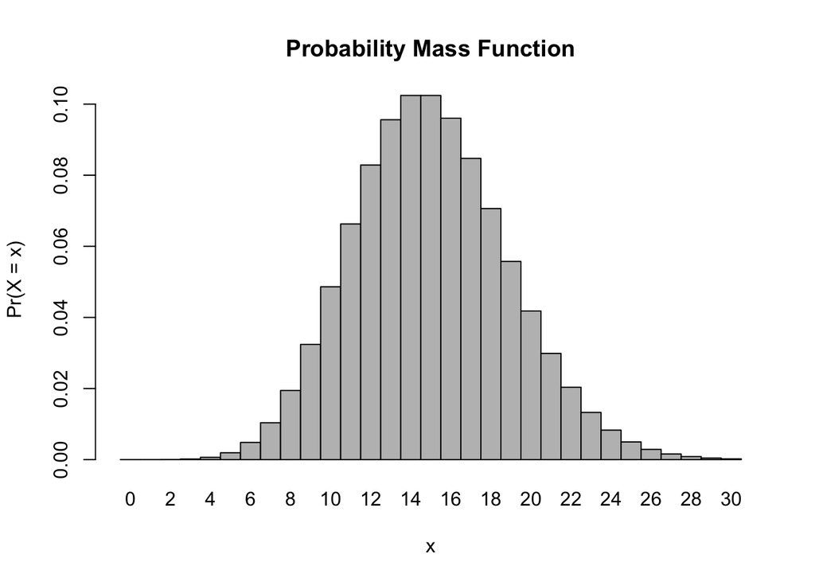

```r
# Plot the relevant Poisson mass function over the values in range 0 ≤ x ≤ 30.
x <- 0:30
l <- 15
probset <- dpois(x = x, lambda = l)
barplot(probset, names.arg = x, space = 0, xlab = "x", ylab = "Pr(X = x)", main = "Probability Mass Function")
```

#challenge 4 - cece comments #Did the same thing, got the same result, lookin good

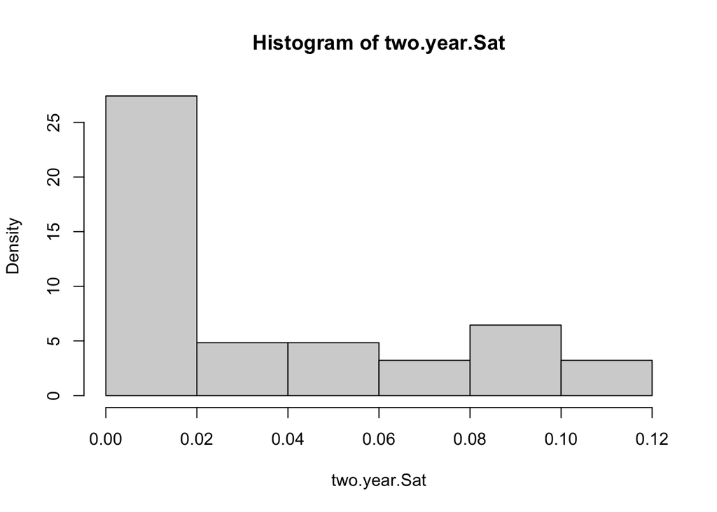

```r
# Simulate 104 results from this distribution (i.e., 2 years of Saturday monitoring sessions).
n.Sat <- 104
Sat <- function(x) {
    dpois(x = 0:30, lambda = 15)
}

two.year.Sat <- Sat(n.Sat)
hist(two.year.Sat, probability = TRUE)
```

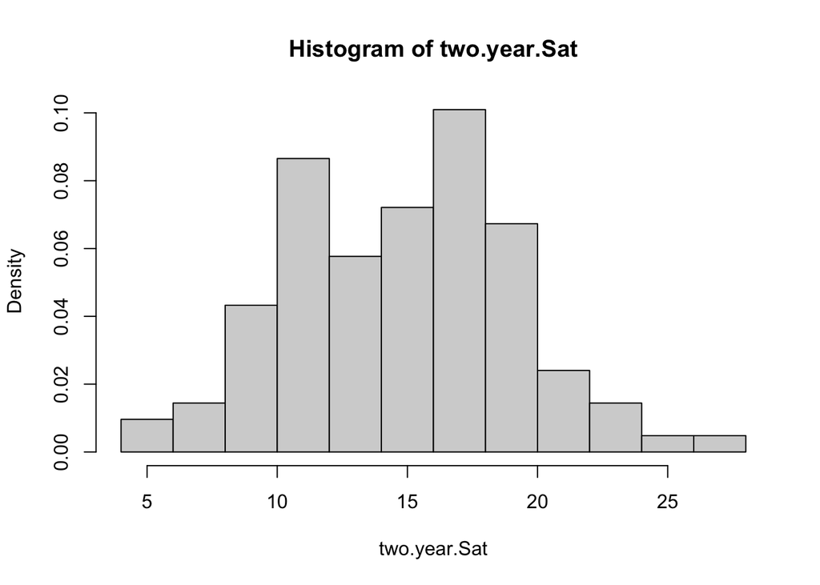

```r
n.Sat <- 104
Sat <- function(x) {
    rpois(104 , lambda = 15)
}
two.year.Sat <- Sat(n.Sat)
hist(two.year.Sat, probability = TRUE)
```

```r
# Cannot figure out how to get results
# dpois() outputs probabilities not number of calls
```

#challenge 5 - cece comments # ok so I used rpois here instead of dpois because rpois can “simulate numbers for a given poisons distribution”. I also did not use a function, because I dont *think* you have to for rpois. you can instead make a data frame with data = rpois (104,15) (104 for the amount of simulated numbers you want and 15 for lambda), and named it “monkeys”, then ran a histogram with hist(monkeys$data)

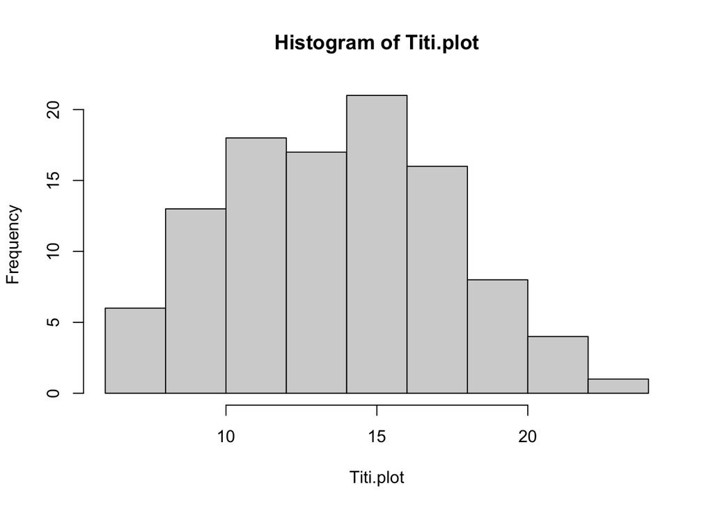

```r
# Plot the simulated results using hist() and use xlim() to set the horizontal limits to be from 0 to 30. How does your histogram compare to the shape of the probability mass function you plotted above?

Titi.plot <- rpois(n = 104, lambda = 15)
hist(Titi.plot)
```

```r
?xlim
# Cannot figure out xlim
# Also this is a way to do what was asked but I am not using code from the last question
```

#challenge 5 pt 2 - cece comments #ok so i think the rpois stuff that you did here is right for simulating 104 results. the histogram looks very similar to mine but the xlim isn’t set as you said. to set xlim do “xlim = c(0,30),” then you’d be all good.